# Where Does The Buck Stop? Economic Conditions & Electoral Volatility

Karnav Popat & Shashwat Agarwal

21/03/2024

## Research Question

We know that voters punish incumbents when the economy goes sour. At what level of governance do voters allocate responsibility for economic underperformance? Any voter in India is under atleast three levels of governance: local represenntation, state government, and central government. In the United States, where popular perception of control is focused on the President, voters tend to punish the President’s party. Does this hold true for India, where economic initiative is (or was) significantly more decentralized?

## Dependent Variable

To measure how voters reward and punish retrospective economic conditions, we use electoral volatility. We can calculate this for each constituency and each election using TCPD’s election datasets.

Some of the indicators used in Dash & Ferris are calculated at the constituency level, rather than being specific to candidate or party. These are the voter turnout (which indicates the level of democratic participation) and Effective Number of Parties (ENOP, which indicates the effective degree of choice that the voter has).

```r
aggregate_electoral_indicators <- assembly %>%
  group_by(State_Name, Year, Constituency_Name)%>%
  summarize(total_votes=sum(Votes), Electors=first(Electors), Turnout_Percentage=first(Turnout_Percentage), ENOP=first(ENOP))
```

Aggregate Electoral Indicators

| State_Name | Year | Constituency_Name | total_votes | Electors | Turnout_Percentage | ENOP |
| --- | --- | --- | --- | --- | --- | --- |
| Andhra_Pradesh | 1962 | ACHAMPET | 25697 | 55158 | 46.59 | 1.92 |
| Andhra_Pradesh | 1962 | ACHANTA | 49098 | 65533 | 74.92 | 2.04 |
| Andhra_Pradesh | 1962 | ADDANKI | 42969 | 69341 | 61.97 | 2.86 |
| Andhra_Pradesh | 1962 | ADILABAD | 36655 | 59503 | 61.60 | 3.03 |
| Andhra_Pradesh | 1962 | ADONI | 44602 | 63617 | 70.11 | 2.27 |
| Andhra_Pradesh | 1962 | ALAIR | 35857 | 56891 | 63.03 | 2.00 |

More comprehensive measures of voting behaviour are calculated from one election to another. Electoral Volatility is expressed as:
$$\frac{\sum_{p=1}^{n}V_{pt} - V_{p(t-1)}}{2}$$
for each party *p* between election *t* and *t-1*. To calculate this, we first widen the dataset to get each party’s voteshare in each election.

```r
assembly <- assembly%>%
  mutate(Year = as.integer(Year))%>%
  filter(Year >= 2021)

# Aggregate the dataframe by party instead of by candidate
partywise_votes <- assembly %>%
  filter(last_poll == TRUE)%>%
  group_by(State_Name, Constituency_No, Constituency_Name, Year, Assembly_No, Party)%>%
  summarize(Votes=sum(Votes), Valid_Votes=sum(Valid_Votes), Electors=first(Electors), Constituency_Type=first(Constituency_Type), Vote_Share_Percentage=sum(Vote_Share_Percentage))%>%
  ungroup()
```

```r
# Extract the list of parties
party_list <- as.list(unique(partywise_votes$Party))

# Widen the dataframe for each party
for (party in party_list) {
  partywise_votes[[paste0("Party_", party)]] <- ifelse(partywise_votes$Party == party, partywise_votes$Vote_Share_Percentage, 0)
}
partywise_votes <- partywise_votes%>%
  dplyr::select(-Party, -Votes, -Valid_Votes)%>%
  group_by(State_Name, Constituency_No, Constituency_Name, Assembly_No, Year, Electors, Constituency_Type)%>%
  summarise_all(.funs = function(x) sum(x))%>%
  ungroup()
```

Party-wise Vote Shares in Assembly Elections

| State_Name | Constituency_No | Constituency_Name | Assembly_No | Year | Electors | Constituency_Type | Vote_Share_Percentage | Party_ | Party_BJP | Party_INC | Party_IND | Party_India Praja Bandhu Party | Party_Jana Sahayaka Sakthi | Party_Mahajana Rajyam Party | Party_Mana Party | Party_Navarang Congress Party | Party_Navataram Party | Party_Telugu Janata Party | Party_YSRCP | Party_NOTA | Party_SUCI | Party_AGP | Party_AIFB | Party_AJP | Party_Rashtriya Ulama Council | Party_Republican Party of India | Party_SP | Party_Rashtriya Lok Samta Party | Party_AIUDF | … |
| --- | --- | --- | --- | --- | --- | --- | --- | --- | --- | --- | --- | --- | --- | --- | --- | --- | --- | --- | --- | --- | --- | --- | --- | --- | --- | --- | --- | --- | --- | --- |
| Andhra_Pradesh | 124 | BADVEL | 15 | 2021 | 216206 | SC | 100.01 | 2.48 | 14.73 | 4.24 | 1.18 | 0.21 | 0.09 | 0.11 | 0.11 | 0.11 | 0.22 | 0.28 | 76.25 | 0.00 | 0.00 | 0.00 | 0.00 | 0.00 | 0.00 | 0.00 | 0.00 | 0.00 | 0.00 | … |
| Assam | 1 | RATABARI | 15 | 2021 | 174037 | SC | 100.00 | 0.00 | 61.92 | 35.44 | 1.24 | 0.00 | 0.00 | 0.00 | 0.00 | 0.00 | 0.00 | 0.00 | 0.00 | 0.88 | 0.52 | 0.00 | 0.00 | 0.00 | 0.00 | 0.00 | 0.00 | 0.00 | 0.00 | … |
| Assam | 2 | PATHARKANDI | 15 | 2021 | 191958 | GEN | 99.99 | 0.00 | 49.66 | 46.70 | 1.88 | 0.00 | 0.00 | 0.00 | 0.00 | 0.00 | 0.00 | 0.00 | 0.00 | 0.85 | 0.07 | 0.36 | 0.06 | 0.17 | 0.12 | 0.12 | 0.00 | 0.00 | 0.00 | … |
| Assam | 3 | KARIMGANJ NORTH | 15 | 2021 | 198599 | GEN | 99.98 | 0.00 | 35.89 | 41.57 | 20.76 | 0.00 | 0.00 | 0.00 | 0.00 | 0.00 | 0.00 | 0.00 | 0.00 | 0.80 | 0.11 | 0.00 | 0.58 | 0.00 | 0.21 | 0.00 | 0.06 | 0.00 | 0.00 | … |
| Assam | 4 | KARIMGANJ SOUTH | 15 | 2021 | 193186 | GEN | 100.00 | 0.00 | 0.00 | 59.16 | 2.17 | 0.00 | 0.00 | 0.00 | 0.00 | 0.00 | 0.00 | 0.00 | 0.00 | 0.66 | 0.00 | 37.54 | 0.00 | 0.00 | 0.00 | 0.00 | 0.00 | 0.47 | 0.00 | … |
| Assam | 5 | BADARPUR | 15 | 2021 | 163832 | GEN | 99.99 | 0.00 | 38.41 | 0.00 | 1.78 | 0.00 | 0.00 | 0.00 | 0.00 | 0.00 | 0.00 | 0.00 | 0.00 | 1.30 | 0.00 | 0.00 | 0.00 | 1.61 | 0.27 | 0.00 | 0.00 | 0.00 | 56.62 | … |
| Assam | 6 | HAILAKANDI | 15 | 2021 | 163559 | GEN | 100.02 | 0.00 | 36.72 | 0.00 | 6.74 | 0.00 | 0.00 | 0.00 | 0.00 | 0.00 | 0.00 | 0.00 | 0.00 | 0.83 | 0.10 | 0.00 | 0.00 | 0.00 | 0.00 | 0.00 | 0.00 | 0.00 | 55.15 | … |
| Assam | 7 | KATLICHERRA | 15 | 2021 | 179800 | GEN | 99.98 | 0.00 | 43.41 | 1.90 | 1.92 | 0.00 | 0.00 | 0.00 | 0.00 | 0.00 | 0.00 | 0.00 | 0.00 | 0.48 | 0.00 | 0.00 | 0.00 | 0.00 | 0.00 | 0.00 | 0.00 | 0.00 | 51.83 | … |
| Assam | 8 | ALGAPUR | 15 | 2021 | 163410 | GEN | 100.02 | 0.00 | 36.42 | 0.00 | 7.81 | 0.00 | 0.00 | 0.00 | 0.00 | 0.00 | 0.00 | 0.00 | 0.00 | 0.33 | 0.00 | 5.59 | 0.41 | 0.00 | 0.00 | 0.00 | 0.00 | 0.00 | 49.46 | … |
| Assam | 9 | SILCHAR | 15 | 2021 | 235365 | GEN | 99.99 | 0.00 | 56.17 | 34.75 | 7.37 | 0.00 | 0.00 | 0.00 | 0.00 | 0.00 | 0.00 | 0.00 | 0.00 | 0.80 | 0.43 | 0.00 | 0.00 | 0.00 | 0.00 | 0.00 | 0.00 | 0.00 | 0.00 | … |

We can now calculate electoral volatility using the Pedersen formula:

```r
# Calculate the volatility by summing the deltas for each party
partywise_deltas <- partywise_votes%>%
  group_by(State_Name, Constituency_No, Constituency_Name)%>%
  mutate_at(vars(starts_with("Party_")),
            funs(abs(. - lag(.))))%>%
  mutate_all(~replace(., is.na(.), 0))%>%
  mutate_at(vars(matches("^Party")), as.numeric)%>%
  ungroup()%>%
  mutate(volatility=rowSums(dplyr::select(., starts_with("Party_")))/2)

volatility <- partywise_deltas%>%
  dplyr::select(State_Name, Constituency_No, Constituency_Name, Year, Assembly_No, volatility)%>%
  filter(volatility != 0)
```

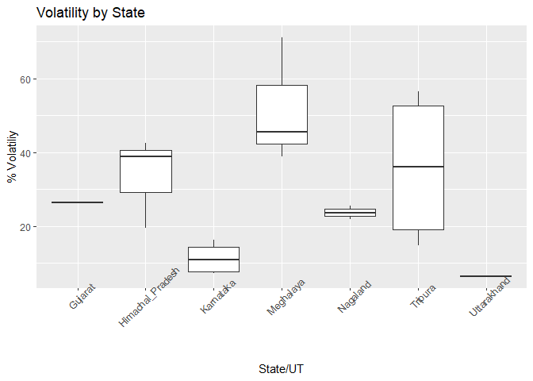

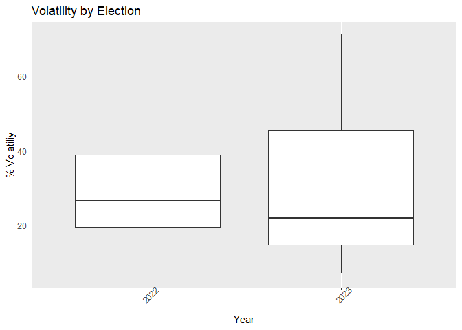

To test our hypothesis, we’d want to narrow this down by calculating electoral volatility separately for the local incumbent party, the ruling state party, and the ruling central party.

## Independent Variable

To measure nationwide economic conditions over time, we use night-lights data as a proxy. This is a well-established though inherently limited practiced. We can get night-lights data from SHRUG.

```r
for (i in 1992:1993) {
  rasterfile <- raster(paste0("../shrug/li/Harmonized_DN_NTL_", as.character(i), "_calDMSP.tif"))
  rasterfile <- crop(rasterfile, ext, snap="out", filename=paste0("../shrug/li/clipped_", as.character(i), "_calDMSP.tif"), overwrite=TRUE)
  assembly_data[paste0("nightlight_", as.character(i))] <- exact_extract(rasterfile, assembly_shp, 'mean', progress=FALSE)
}
```

```r
for (i in 2014:2019) {
  rasterfile <- raster(paste0("../shrug/li/Harmonized_DN_NTL_", as.character(i), "_simVIIRS.tif"))
  rasterfile <- crop(rasterfile, ext, snap="out", filename=paste0("../shrug/li/clipped_", as.character(i), "_simVIIRS.tif"), overwrite=TRUE)
  assembly_data[paste0("nightlight_", as.character(i))] <- exact_extract(rasterfile, assembly_shp, 'mean', progress=FALSE)
}
```

| state | ac_no | ac_name | geometry | nightlight_1992 | nightlight_1993 | nightlight_2014 | nightlight_2015 | nightlight_2016 | nightlight_2017 | nightlight_2018 | nightlight_2019 |
| --- | --- | --- | --- | --- | --- | --- | --- | --- | --- | --- | --- |
| Andhra Pradesh | 1 | Sirpur | MULTIPOLYGON (((79.55699 19… | 0.4110492 | 0.5352790 | 6.520885 | 6.861316 | 5.723174 | 7.150575 | 7.184897 | 7.465248 |
| Andhra Pradesh | 2 | Chennur | MULTIPOLYGON (((79.90563 19… | 1.8471193 | 2.2658546 | 8.210689 | 8.772991 | 8.072450 | 9.727179 | 10.589094 | 10.717432 |
| Andhra Pradesh | 3 | Bellampalli | MULTIPOLYGON (((79.908 19.1… | 1.7101592 | 2.2283971 | 7.134856 | 7.384798 | 6.633897 | 7.965139 | 8.191889 | 8.861242 |
| Andhra Pradesh | 4 | Mancherial | MULTIPOLYGON (((79.10574 19… | 5.5511055 | 6.3680191 | 11.161736 | 11.697873 | 11.288451 | 12.719646 | 13.757302 | 14.964783 |
| Andhra Pradesh | 5 | Asifabad | MULTIPOLYGON (((78.73274 19… | 0.4894921 | 0.5649003 | 6.489279 | 6.791655 | 6.141421 | 7.483316 | 7.489865 | 7.549194 |
| Andhra Pradesh | 6 | Khanapur | MULTIPOLYGON (((78.59774 19… | 1.3173398 | 2.2638988 | 6.806900 | 7.355008 | 6.694963 | 7.929931 | 7.965712 | 8.267973 |
| Andhra Pradesh | 7 | Adilabad | MULTIPOLYGON (((78.59774 19… | 2.9263520 | 4.4463348 | 8.882252 | 8.972123 | 8.872417 | 9.928370 | 10.307904 | 10.852538 |
| Andhra Pradesh | 8 | Boath | MULTIPOLYGON (((78.51174 19… | 1.0058302 | 2.1589508 | 6.802576 | 6.951147 | 6.700504 | 7.632126 | 8.012551 | 8.481970 |
| Andhra Pradesh | 9 | Nirmal | MULTIPOLYGON (((78.16924 19… | 3.7716072 | 4.7362690 | 8.226339 | 8.968479 | 8.524355 | 9.783505 | 10.899914 | 11.800275 |
| Andhra Pradesh | 10 | Mudhole | MULTIPOLYGON (((78.16924 19… | 2.3071134 | 3.8311601 | 7.286399 | 7.500532 | 7.277654 | 8.230984 | 9.772959 | 9.827282 |

```
## Deleting source `./data/nightlights_constituency.shp' using driver `ESRI Shapefile'
## Writing layer `nightlights_constituency' to data source
##   `./data/nightlights_constituency.shp' using driver `ESRI Shapefile'
## Writing 4074 features with 11 fields and geometry type Multi Polygon.
```

```r
parties <- assembly %>%
  group_by(State_Name, Constituency_Name, Year) %>%
  summarize(Parties=list(unique(Party)))%>%
  arrange(State_Name, Constituency_Name, Year)%>%
  mutate(
    Prev_Parties=ifelse(
      lag(State_Name) == State_Name & lag(Constituency_Name) == Constituency_Name,
      lag(Parties),
      NA
    )
  )%>%
  rowwise()%>%
  mutate(Continuing_Parties = list(intersect(Prev_Parties, Parties)))
```

Parties contesting each Assembly Election

| State_Name | Constituency_Name | Year | Parties | Prev_Parties | Continuing_Parties |
| --- | --- | --- | --- | --- | --- |
| Andhra_Pradesh | BADVEL | 2021 | YSRCP , BJP , INC , , IND , Telugu Janata Party , Navataram Party , India Praja Bandhu Party, Mana Party , Mahajana Rajyam Party , Navarang Congress Party , Jana Sahayaka Sakthi | NULL | NULL |
| Assam | ABHAYAPURI NORTH | 2021 | INC , AGP , AITC , AJP , NOTA , IND , JD(U) | NULL | NULL |
| Assam | ABHAYAPURI SOUTH | 2021 | INC , AGP , IND , NOTA | NULL | NULL |
| Assam | ALGAPUR | 2021 | AIUDF, BJP , AGP , IND , AIFB , NOTA | NULL | NULL |
| Assam | AMGURI | 2021 | AGP , INC , AJP , NOTA, IND | NULL | NULL |
| Assam | BADARPUR | 2021 | AIUDF , BJP , AJP , NOTA , IND , Rashtriya Ulama Council | NULL | NULL |